# 05 · Set association

## Load packages

`enrichVolcano` (not on CRAN) is called with `::` for its label cleaner.

```r
pacman::p_load(
  here, limpa, limma, dplyr, tibble, tidyr, purrr, stringr, ggplot2, readr, readxl, writexl
)
here::i_am("03_Pathway_Enrichment/05_set_association/a_script/05_set_association.qmd")
```

## Read inputs

Association asks whether the sets that move with training move more in legs that grew more. The protein-association inputs are read in their own section.

```r
stage <- here("03_Pathway_Enrichment", "05_set_association")
gene_sets <- here("03_Pathway_Enrichment", "00_build_gene_sets", "c_data")
set_catalog <- read_excel(file.path(gene_sets, "00_build_gene_sets.xlsx"), "set_catalog")
set_score <- readRDS(here("03_Pathway_Enrichment", "03_run_singscore", "c_data", "set_scores.rds"))
proteins <- readRDS(here("01_Preprocess", "02_Quantification", "c_data", "proteins.rds"))
phenotype <- read_csv(here("00_Input", "phenotype.csv"), show_col_types = FALSE)
catalog <- set_catalog |>
  filter(qualifies) |>
  select(set_id, database, pathway)
values <- set_score[catalog$set_id, ]
table(catalog$database)
```

```
    GO_Slim        GOBP    Hallmark KEGG_Legacy    Reactome
         59        1366          41          94         430
```

## Pair the samples

Each leg’s score change is T2 minus T1. Treatment comes from the targets, never the leg letter: leg assignment was counterbalanced.

```r
legs <- proteins$targets |>
  mutate(leg_id = paste(participant, leg, sep = "_")) |>
  select(leg_id, participant, leg, treatment, timepoint, sample_id) |>
  pivot_wider(names_from = timepoint, values_from = sample_id) |>
  drop_na(T1, T2) |>
  arrange(participant, treatment)
delta_pairs <- legs |>
  select(participant, treatment, leg_id) |>
  pivot_wider(names_from = treatment, values_from = leg_id) |>
  drop_na(BFR, HLRT)
c(legs = nrow(legs), change = nrow(delta_pairs))
```

```
  legs change
    65     32
```

```r
delta <- values[, legs$T2] - values[, legs$T1]
colnames(delta) <- legs$leg_id
```

## Prepare the phenotype

Four outcomes, each a post minus pre change in one leg: cross-sectional area (`csa`) and echo intensity (`echo`) of vastus lateralis (`vl`) and rectus femoris (`rf`). Echo falls as muscle composition improves.

```r
# One-to-one: a duplicated phenotype row would misalign every leg.
outcomes <- c("vl_csa", "vl_echo", "rf_csa", "rf_echo")
leg_phenotype <- legs |>
  left_join(
    select(phenotype, -treatment),
    by = c("participant", "leg"), relationship = "one-to-one"
  ) |>
  mutate(
    vl_csa = vl_csa_post_cm2 - vl_csa_pre_cm2,
    vl_echo = vl_echo_post_au - vl_echo_pre_au,
    rf_csa = rf_csa_post_cm2 - rf_csa_pre_cm2,
    rf_echo = rf_echo_post_au - rf_echo_pre_au
  )
```

The within-participant analysis takes BFR minus HLRT for the score change and each outcome change, so participant traits that move both legs cancel.

```r
paired <- delta[, delta_pairs$BFR] - delta[, delta_pairs$HLRT]
colnames(paired) <- delta_pairs$participant
paired_outcome <- map(set_names(outcomes), function(name) {
  value <- set_names(leg_phenotype[[name]], leg_phenotype$leg_id)
  value[delta_pairs$BFR] - value[delta_pairs$HLRT]
})
```

## Correlate each set

Spearman correlation is not pulled by single extreme legs. `cor.test()` uses AS 89, an Edgeworth approximation at the 32 and 65 observations here, so p is not exact. BH runs within each analysis, outcome and collection.

```r
# Tied singscore changes make cor.test() warn and fall back to the t approximation.
spearman_by_row <- function(x, outcome) {
  fits <- suppressWarnings(apply(x, 1, function(row) {
    test <- cor.test(row, outcome, method = "spearman")
    c(r = unname(test$estimate), p = test$p.value)
  }))
  tibble(
    set_id = rownames(x), n = sum(!is.na(outcome)),
    r = unname(fits["r", ]), p = unname(fits["p", ])
  )
}
set_association <- map(set_names(outcomes), function(name) {
  bind_rows(
    all_legs = spearman_by_row(delta, leg_phenotype[[name]]),
    within_participant = spearman_by_row(paired, paired_outcome[[name]]),
    .id = "analysis"
  ) |>
    mutate(outcome = name)
}) |>
  list_rbind() |>
  relocate(analysis, outcome) |>
  left_join(select(catalog, set_id, database, pathway), by = "set_id") |>
  mutate(fdr = p.adjust(p, "BH"), .by = c(analysis, outcome, database))
```

The all-legs analysis counts a participant’s two legs as independent; the median Spearman r between a participant’s BFR and HLRT leg changes, across sets, checks that.

```r
leg_r <- map_dbl(rownames(delta), function(id) {
  cor(delta[id, delta_pairs$BFR], delta[id, delta_pairs$HLRT], method = "spearman")
})
round(median(leg_r), 3)
```

```
[1] -0.021
```

The same correlation inside each arm, not adjusted, feeds the all-legs figure insets.

```r
by_arm <- map(set_names(c("BFR", "HLRT")), function(treatment) {
  keep <- leg_phenotype$treatment == treatment
  map(set_names(outcomes), function(name) {
    spearman_by_row(delta[, keep], leg_phenotype[[name]][keep]) |>
      mutate(outcome = name)
  }) |>
    list_rbind()
}) |>
  list_rbind(names_to = "treatment")
```

## Compare with chance

Sets co-vary, so a nominal count means little alone; its ratio to 5% of the sets tested reads 1 at chance, with one denominator per collection as in `04_`.

```r
# The ratio divides by the unrounded expectation, not the rounded `expected` column.
chance_expectation <- set_association |>
  transmute(
    analysis = paste0("association: ", analysis), comparison = outcome, database,
    n_pairs = n, p, fdr
  ) |>
  summarise(
    features = n(), nominal = sum(p < 0.05), expected = round(n() * 0.05, 1),
    ratio = round(nominal / (n() * 0.05), 2), fdr_sig = sum(fdr < 0.05),
    .by = c(analysis, comparison, database, n_pairs)
  )
```

```r
chance_expectation |>
  select(analysis, comparison, database, ratio) |>
  pivot_wider(names_from = database, values_from = ratio)
```

```
# A tibble: 8 × 7
  analysis                comparison Hallmark Reactome KEGG_Legacy  GOBP GO_Slim
  <chr>                   <chr>         <dbl>    <dbl>       <dbl> <dbl>   <dbl>
1 association: all_legs   vl_csa         0        0.37        1.49  1.02    1.02
2 association: within_pa… vl_csa         0        0.37        0.43  0.35    0.34
3 association: all_legs   vl_echo        0.98     0.47        0.21  0.6     0
4 association: within_pa… vl_echo        0.98     0.6         1.06  0.94    0.34
5 association: all_legs   rf_csa         1.95     0.37        0.64  0.79    0.68
6 association: within_pa… rf_csa         0.49     0.28        0.85  0.61    0
7 association: all_legs   rf_echo        0        0.56        1.91  0.63    0.34
8 association: within_pa… rf_echo        0.49     0.74        2.55  0.91    1.36
```

```r
summarise(chance_expectation, fdr_sig = sum(fdr_sig), .by = c(analysis, comparison))
```

```
# A tibble: 8 × 3
  analysis                        comparison fdr_sig
  <chr>                           <chr>        <int>
1 association: all_legs           vl_csa           0
2 association: within_participant vl_csa           0
3 association: all_legs           vl_echo          0
4 association: within_participant vl_echo          0
5 association: all_legs           rf_csa           0
6 association: within_participant rf_csa           0
7 association: all_legs           rf_echo          0
8 association: within_participant rf_echo          0
```

## Rank sets on the protein association

Set scores ignore the protein model’s precision weights, so sets are also tested on the protein slopes of `03_Protein_Association`, which keep them: `average` over BFR and HLRT and `difference`, BFR minus HLRT. As in `01_`, fgsea gives leads and fry confirms.

```r
association_t <- readRDS(here(
  "02_Differential_Expression", "03_Protein_Association", "c_data", "association_t.rds"
))
sets <- readRDS(file.path(gene_sets, "gene_sets.rds"))
gene_of <- read_excel(file.path(gene_sets, "00_build_gene_sets.xlsx"), "protein_gene_map") |>
  filter(selected)
set.seed(1)
association_fgsea <- map(set_names(colnames(association_t)), function(column) {
  stats <- set_names(association_t[gene_of$protein, column], gene_of$gene)
  fgsea::fgsea(sets, stats, minSize = 15, maxSize = 500) |>
    as_tibble() |>
    mutate(leadingEdge = map_chr(leadingEdge, str_flatten, ";"))
}) |>
  list_rbind(names_to = "ranking") |>
  separate_wider_delim(ranking, "_", names = c("coefficient", "outcome"), too_many = "merge") |>
  rename(set_id = pathway) |>
  left_join(select(set_catalog, set_id, database), by = "set_id")
```

fry tests the same coefficient on each ranking’s saved design, with that design’s `dpcDE()` precision weights.

```r
association_designs <- readRDS(here(
  "02_Differential_Expression", "03_Protein_Association", "c_data", "association_designs.rds"
))
set_rows <- map(sets, function(genes) {
  match(gene_of$protein[match(genes, gene_of$gene)], rownames(proteins))
})
association_fry <- imap(association_designs, function(model, ranking) {
  stopifnot(nrow(model$design) == ncol(proteins))
  proteins$weights <- dpcDE(proteins, model$design, plot = FALSE)$EList$weights
  fry(
    proteins, set_rows, model$design,
    contrast = model$contrast, robust = TRUE, sort = "none"
  ) |>
    rownames_to_column("set_id") |>
    transmute(ranking, set_id, fry_direction = Direction, fry_p = PValue, fry_fdr = FDR)
}) |>
  list_rbind() |>
  separate_wider_delim(ranking, "_", names = c("coefficient", "outcome"), too_many = "merge")
association_sets <- left_join(
  association_fgsea, association_fry, by = c("coefficient", "outcome", "set_id")
)
association_sets |>
  summarise(
    fgsea = sum(padj < 0.05), fry = sum(fry_fdr < 0.05), fry_min_fdr = signif(min(fry_fdr), 3),
    .by = c(coefficient, outcome)
  )
```

```
# A tibble: 10 × 5
   coefficient outcome       fgsea   fry fry_min_fdr
   <chr>       <chr>         <int> <int>       <dbl>
 1 difference  vl_csa           33     0      0.998
 2 average     vl_csa          137     0      0.997
 3 difference  vl_echo         148     0      0.227
 4 average     vl_echo           0     0      0.996
 5 difference  rf_csa            4     0      1
 6 average     rf_csa          136     0      0.816
 7 difference  rf_echo         231     0      0.588
 8 average     rf_echo          48     0      0.999
 9 difference  volume_load_t   215     0      0.0929
10 average     volume_load_t   272    59      0.0481
```

## Draw figures

Every set-outcome pair at nominal p is drawn, so the reader can judge each correlation by eye. S11 plots each leg with a line per arm; S12 plots what was tested, one BFR minus HLRT difference per participant.

```r
figure_theme <- theme_minimal(base_size = 9) +
  theme(
    strip.text = element_text(size = 6.8, lineheight = 1.2, margin = margin(3, 3, 4, 3)),
    panel.grid.minor = element_blank(),
    panel.spacing = unit(4, "mm"),
    legend.position = "top"
  )
# Pages are built from their own rows: a paginating facet would build every panel for every page.
association_figure <- function(which_analysis, number, title, db) {
  hits <- set_association |>
    filter(analysis == which_analysis, database == db, p < 0.05) |>
    arrange(p)
  if (nrow(hits) == 0) {
    return(list())
  }
  per_participant <- which_analysis == "within_participant"
  if (per_participant) {
    score_change <- paired
    phenotype_change <- paired_outcome
    point_series <- "BFR - HLRT"
    x_label <- "change in set score, T2 - T1, BFR minus HLRT, one point per participant"
    y_label <- "change in phenotype, BFR minus HLRT"
    headroom <- 0.06
  } else {
    score_change <- delta
    phenotype_change <- leg_phenotype
    point_series <- leg_phenotype$treatment
    x_label <- "change in set score, T2 - T1, one point per leg"
    y_label <- "change in phenotype"
    headroom <- 0.35
  }
  points <- pmap(hits, function(set_id, database, pathway, outcome, r, p, fdr, ...) {
    arms <- by_arm |>
      filter(set_id == !!set_id, outcome == !!outcome) |>
      mutate(text = sprintf("%-5s n=%d  r=%+.2f  p=%.3f", treatment, n, r, p))
    label <- paste0(database, ": ", enrichVolcano::clean_label(pathway, width = 1000))
    tibble(
      panel = sprintf(
        "%s\nvs %s   r = %+.2f   p %s   q %s",
        str_wrap(label, 40), outcome, r, signif(p, 2), signif(fdr, 2)
      ),
      change = score_change[set_id, ], d_outcome = phenotype_change[[outcome]],
      series = point_series, inset = if (per_participant) "" else paste(arms$text, collapse = "\n")
    )
  }) |>
    list_rbind() |>
    mutate(panel = factor(panel, levels = unique(panel)))
  pages <- unname(split(points, (as.integer(points$panel) - 1) %/% 12))
  imap(pages, function(page, i) {
    page <- droplevels(page)
    page_note <- if (length(pages) > 1) sprintf(" (page %d of %d)", i, length(pages)) else ""
    ggplot(page, aes(change, d_outcome, colour = series, fill = series)) +
      geom_hline(yintercept = 0, linewidth = 0.25, colour = "grey85") +
      geom_vline(xintercept = 0, linewidth = 0.25, colour = "grey85") +
      geom_smooth(method = "lm", formula = y ~ x, se = TRUE, alpha = 0.12, linewidth = 0.5) +
      geom_point(size = 1.2, alpha = 0.9) +
      geom_text(
        data = distinct(page, panel, inset), inherit.aes = FALSE,
        aes(x = -Inf, y = Inf, label = inset), family = "mono",
        hjust = -0.05, vjust = 1.25, size = 1.9, lineheight = 1.2, colour = "grey25"
      ) +
      scale_y_continuous(expand = expansion(mult = c(0.06, headroom))) +
      scale_colour_manual(
        values = c(BFR = "#B2182B", HLRT = "#2166AC", `BFR - HLRT` = "grey25"),
        aesthetics = c("colour", "fill"), name = NULL
      ) +
      facet_wrap(~panel, ncol = 3, nrow = 4, scales = "free") +
      labs(
        x = x_label, y = y_label,
        title = sprintf("S%d. %s, %s%s", number, title, db, page_note)
      ) +
      figure_theme
  })
}
```

S13 draws each chance ratio as a bar, one panel per analysis and outcome.

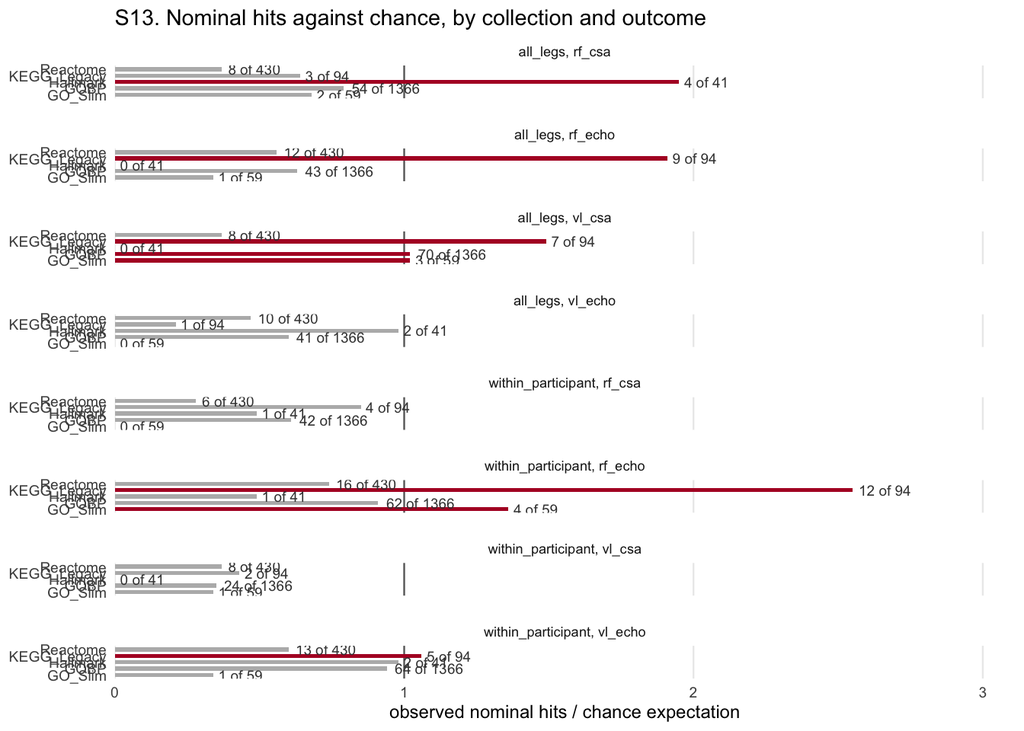

```r
chance_plot <- chance_expectation |>
  mutate(panel = paste0(sub("association: ", "", analysis), ", ", comparison)) |>
  ggplot(aes(ratio, database, fill = ratio > 1)) +
  geom_vline(xintercept = 1, linewidth = 0.4, colour = "grey40") +
  geom_col(width = 0.65) +
  geom_text(
    aes(label = sprintf("%d of %d", nominal, features)),
    hjust = -0.12, size = 2.5, colour = "grey25"
  ) +
  facet_wrap(~panel, ncol = 1) +
  scale_fill_manual(values = c(`TRUE` = "#B2182B", `FALSE` = "grey72"), guide = "none") +
  scale_x_continuous(expand = expansion(mult = c(0, 0.22))) +
  labs(
    x = "observed nominal hits / chance expectation", y = NULL,
    title = "S13. Nominal hits against chance, by collection and outcome"
  ) +
  figure_theme +
  theme(panel.grid.major.y = element_blank())
chance_plot
```

One PDF: S13 first, then S11 and S12 per collection.

```r
collection_order <- c("Hallmark", "GO_Slim", "KEGG_Legacy", "Reactome", "GOBP")
stopifnot(setequal(collection_order, catalog$database))
pdf(file.path(stage, "b_reports", "05_set_association.pdf"), width = 8.27, height = 11.69)
print(chance_plot)
for (db in collection_order) {
  walk(association_figure("all_legs", 11, "Association over all legs", db), print)
  walk(
    association_figure("within_participant", 12, "Within participant, BFR minus HLRT", db), print
  )
}
invisible(dev.off())
```

## Save results

```r
write_xlsx(
  list(
    chance_expectation = chance_expectation,
    set_association = arrange(set_association, p),
    set_by_arm = by_arm,
    association_sets = arrange(association_sets, pval)
  ),
  file.path(stage, "c_data", "05_set_association.xlsx")
)
```